Dipam’s Notebook

# Frost Diagrams

March 07, 2025

This is an explanation of Frost diagrams - what they are, what do they show, and how they can be used to determine the stability of species in different oxidation states. There is lot of confusion around the topic, given that the Wikipedia page on the topic has incorrect information (at the time of writing).

## Redox Reactions

A redox reaction is one, where the oxidation state of its reactants changes. In such a reaction, two processes - oxidation and reduction - occur simultaneously. For example, in the reaction between zinc and copper ions, zinc is oxidized to zinc ions, while copper ions are reduced to copper. The reaction can be written as follows:

$$Zn+Cu2+→Zn2++Cu$$

where we have the following half-reactions:

$$Oxidation:Zn→Zn2++2e−$$
$$Reduction:Cu2++2e−→Cu$$

For any half reaction, we can define its standard reduction potential ($𝐸red⚬$), which is the potential difference between the electrode and the electrolyte, under standard conditions (for the reduction half-reaction).

For a redox reaction, we can define the standard cell potential ($𝐸cell⚬$) as the difference between the standard reduction potentials of the reduction and oxidation half-reactions:

$$𝐸cell⚬=𝐸cat⚬−𝐸an⚬$$

where $𝐸cat⚬$ is the standard reduction potential of the cathode and $𝐸an⚬$ is the standard reduction potential of the anode.

The standard cell potential can be used to determine the feasibility of a redox reaction. If the standard cell potential is positive, the reaction is spontaneous, while if it is negative, the reaction is non-spontaneous. This can be directly related to the Gibbs free energy change of the reaction:

$$Δ𝐺⚬=−𝑛𝐹𝐸cell⚬$$

where $𝑛$ is the number of electrons transferred in the reaction and $𝐹$ is the Faraday constant.

## Latimer Diagrams

A given element can exist in multiple different oxidation states. For example, oxygen can exist in 0, −1 or −2 oxidation states. Now, we want to summarise the redox behaviour of these species in a diagram. We can write all the species in order of their oxidation state (from the most oxidised form to the most reduced form), and write the standard reduction potential for different half reactions on arrows connecting the species. This diagram is called a Latimer diagram.

$$O2+2H++2e−→H2O2𝐸⚬=0.68𝑉$$
$$H2O2+2H++2e−→2H2O𝐸⚬=1.78𝑉$$
$$O2+4H++4e−→2H2O𝐸⚬=1.23𝑉$$

Note that the potentials are not additive. For a successive reaction, the free energy change is the sum of the free energy changes of the individual reactions. The standard cell potential is a weighted average of the standard reduction potentials of the half-reactions:

$$Δ𝐺=Δ𝐺1+Δ𝐺2⇒−(𝑛1+𝑛2)𝐹𝐸⚬=−𝑛1𝐹𝐸1⚬−𝑛2𝐹𝐸2⚬⇒𝐸⚬=𝑛1𝐸1⚬+𝑛2𝐸2⚬𝑛1+𝑛2$$

So, thus we have

$$𝐸⚬(O2→H2O)=(2×𝐸⚬(O2→H2O2)+2×𝐸⚬(H2O2→H2O))4=(2×0.68V+2×1.78V)4=1.23V$$

Say we want to find the standard reduction potential for the half-reaction:

$$HClO(aq)+H+(aq)+2e−→Cl−(aq)+H2O(l)$$

$$2HClO+2H++2e−→Cl2+2H2O𝐸⚬=1.63𝑉Cl2+2e−→2Cl−𝐸⚬=1.36𝑉$$

Hence,

$$Δ𝐺1=−𝑛1𝐹𝐸1⚬=−2𝐹×1.63VΔ𝐺2=−𝑛2𝐹𝐸2⚬=−2𝐹×1.36V$$
$$Δ𝐺=Δ𝐺1+Δ𝐺2=−2𝐹×(1.63V+1.36V)−4𝐹×𝐸⚬=−2𝐹×(1.63V+1.36V)𝐸⚬=1.63V+1.36V2=1.5V$$

### Disproportionation

A disproportionation reaction is a type of redox reaction in which a single species of intermediate oxidation state, is both oxidized and reduced. For example, the reaction of chlorine with sodium hydroxide:

$$3Cl2+6OH−→5Cl−+ClO3−+3H2O$$

This is composed of the following half-reactions:

$$Cl2+2e−→2Cl−𝐸⚬=1.36𝑉Cl2+12OH−→2ClO3−+6H2O+10e−𝐸⚬=−0.37𝑉$$

Hence, the standard cell potential can be calculated as:

$$2Δ𝐺=5Δ𝐺1+Δ𝐺2⇒2×(−10𝐹𝐸cell⚬)=5×(−2𝐹𝐸1⚬)+(−10𝐹𝐸2⚬)⇒𝐸⚬=1.36V−0.37V2=0.495V$$

In general we can say, for a disproportionation reaction:

$$𝐸⚬=𝐸red⚬+𝐸ox⚬2$$

Thus, for disproportionation to be spontaneous, on the Latimer diagram, **the left half-reaction must have a lower standard reduction potential than the right half-reaction**.

Another example of a disproportionation is $H2O2$, which disproportionates into $H2O$ and $O2$. Its feasibility is clear from the Latimer diagram of oxygen.

## Motivation

Now, since potentials are not additive, let’s try to find the free energy of each species instead. Consider the free energy of $N2$ to be 0.

$$𝐺(HNO2)=Δ𝐺(N2→HNO2)=Δ𝐺1+Δ𝐺2+Δ𝐺3=−1𝐹(−1.77)−1𝐹(−1.59)−1𝐹(−0.996)=−𝐹(−1.77−1.59−0.996)=𝐹(4.356)$$

Similarly, if we find the free energy of each species, we get

| $NO3−$ | $N2O4$ | $HNO2$ | $NO$ | $N2O$ | $N2$ | $NH3OH+$ | $N2H5+$ | $NH4+$ |
| --- | --- | --- | --- | --- | --- | --- | --- | --- |
| $6.229𝐹$ | $5.426𝐹$ | $4.356𝐹$ | $3.36𝐹$ | $1.77𝐹$ | $0$ | $1.87𝐹$ | $0.46𝐹$ | $−0.815𝐹$ |

The above data gives a clear picture of the stability of the species. For example, $NH4$

+ is the most stable species, while $NO3−$ is the least stable.

Similarly we can find the standard potentials for other half-reactions:

$$−𝑛𝐹𝐸⚬(X→Y)=𝐺(Y)−𝐺(X)⇒𝐸⚬(X→Y)=−1𝐹𝐺(Y)−𝐺(X)|𝑁𝑌−𝑁𝑋|$$

where $𝑁$ represents oxidation state, and $|𝑁𝑌−𝑁𝑋|$ is the number of electrons transferred in the reduction half-reaction.

Consider the $𝐸red⚬$ values for half reactions involving $(N2,X)$. Here, $Δ𝐺=𝐺(𝑋)$. Then,

$$−𝑛𝐹𝐸⚬(N2→X)=𝐺(X)⇒𝐸⚬(N2→X)=−𝐺(X)|𝑁𝑋|𝐹$$

Now, if oxidation state of $𝑋$ is negative, then it is a reduction half-reaction. So, $𝐸red⚬=−𝐺(𝑋)(−𝑁𝑋)𝐹=𝐺(𝑋)𝑁𝑋𝐹$.

If the oxidation state of $𝑋$ is positive, then it is an oxidation half-reaction. So, $𝐸ox⚬=−𝐺(𝑋)𝑁𝑋𝐹$. $𝐸red⚬=𝐺(𝑋)𝑁𝑋𝐹$

Notice that in either case, we get

$$𝐸red⚬=𝐺(𝑋)𝑁𝑋𝐹⇒𝑁𝑋𝐸red⚬=𝐺(𝑋)𝐹$$

Thus, the product of the oxidation state and the standard reduction potential for the half reaction (involving elemental form of the species), is proportional to the free energy of the species, and indicates the stability of the species.

## Frost Diagrams

A Frost diagram is a plot between $𝑁𝐸red⚬$ vs $𝑁$, where $𝑁$ is the oxidation state of the species. It is made relative to the elemental form of the species.

For example, the Frost diagram of Nitrogen in acidic and basic conditions is shown below:

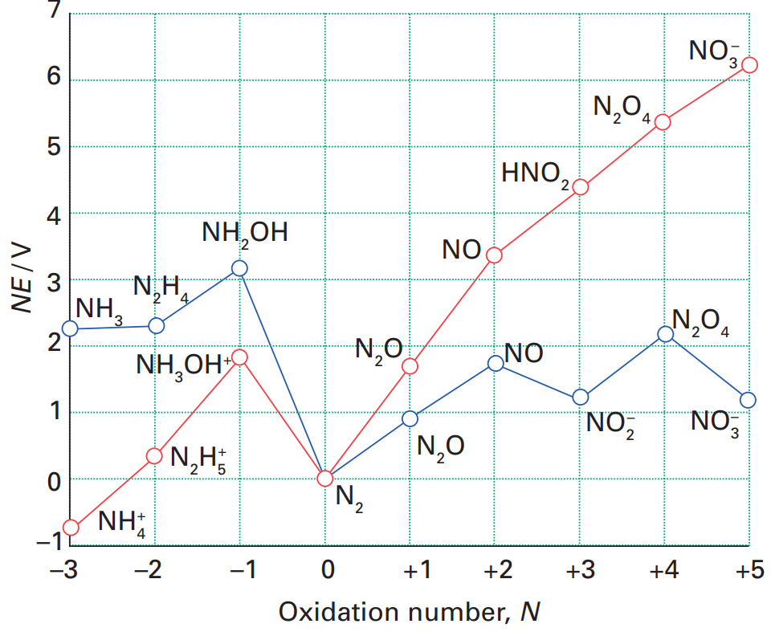

Figure 5: Frost diagram for Nitrogen. (red - acidic, blue - basic)

In this diagram, the height of each point shows the free energy of the species. Thus we can identify that $NH4$

+ is the most stable species, while $NO3−$ is the least stable (in acidic conditions).

Furthurmore, **the slope of the line connecting two points is the standard reduction potential of the half-reaction between the two species**.

Here is the justification for the slope: Consider two species $𝑋$ and $𝑌$ with oxidation states $𝑁𝑋>𝑁𝑌$.

$$Δ𝐺(N2→Y)=Δ𝐺(N2→X)+Δ𝐺(X→Y)⇒|𝑁𝑌|𝐸⚬(N2→Y)=|𝑁𝑋|𝐸⚬(N2→X)+(𝑁𝑋−𝑁𝑌)𝐸⚬(X→Y)$$

Here, notice that $|𝑁𝑌|𝐸⚬(N2→Y)$ is the same as $−𝑁𝑌𝐸red⚬𝑌$. This is because:

- If $𝑁𝑌>0$ then $N2→Y$ is an oxidation reaction and $𝐸red⚬𝑌$ will be negative of $𝐸⚬(N2→Y)$
- If $𝑁𝑌<0$ then $N2→Y$ is a reduction reaction and $𝐸red⚬𝑌$ will be equal to $𝐸⚬(N2→Y)$

So on substituting, we get:

$$⇒𝑁𝑌𝐸red⚬𝑌=𝑁𝑋𝐸red⚬𝑋+(𝑁𝑌−𝑁𝑋)𝐸⚬(X→Y)⇒𝐸⚬(X→Y)=𝑁𝑌𝐸red⚬𝑌−𝑁𝑋𝐸red⚬𝑋𝑁𝑌−𝑁𝑋$$

Thus, the slope of the line connecting two points on the Frost diagram is the standard reduction potential of the half-reaction between the two species.

The steepness of a line is the measure of the tendency of the couple to react in the direction yielding the product having lower free energy.

From the Frost curve, we can also find species unstable to disproportionation, and species stable to comproportionation.

## References

- Frost, Arthur (1951). “Oxidation Potential–Free Energy Diagrams”. Journal of the American Chemical Society. 73 (6): 2680–2682. doi:10.1021/ja01150a074 (https://pubs.acs.org/doi/abs/10.1021/ja01150a074)
- Shriver (2010). Inorganic Chemistry. W. H. Freeman & Co.